# Praca nosql

Mateusz Miotk

08.11.2014

```
Sprzęt:
Laptop ACER ASPIRE ONE 5820TG
Procesor: Intel core I5-430M
Ilość pamięci RAM: 4 GB
Dysk twardy: SSD SanDisk 128 GB
System Operacyjny: Linux Mint 17 x64
Wersja MongoDB: 2.6.5 oraz 2.8.0.rc0
Wersja PostgreSQL: 9.3.5
```

#### Wstęp: Przetworzenie danych Train.csv

1. Do rozpakowania pliku Train.zip użyłem programu **pigz**, który rozpakowuje plik wykorzystując wszystkie rdzenie procesora.
2. Ponieważ plik Train.csv nie jest typowym plikiem .csv, gdyż rekordy nie są przechowywane w jednej linii, musimy pozbyć się znaków nowej linii. Ponadto, ponieważ jest to plik w systemie DOS, to musimy zastąpić znaki powrotu karetki na znaki nowej linii. Dokonujemy to poleceniem:

```bash
  tr -d "\n" < input_file | tr "\r" "\n" > output_file
```

Powyższe polecenie wykorzystuje wyłącznie dwa rdzenie procesora.

3. Ponieważ plik Train.csv zawiera unikatowe pole id, to aby nie powielać tych danych w bazie usuniemy ją z pliku.

Czasy wykonania etapów przedstawiłem w poniższej tabelce:

| Etap | Czas wykonania |
| --- | --- |
| Rozpakowanie pliku | 5 m |
| Zamiana formatu danych | 5 m |

### Zadanie 1a: Zaimportuj bazę danych do PostgresSQL oraz MongoDB.

Do zaimportowania danych w postgreSQL użyłem polecenia:

```sql
  COPY from <nazwa_tabeli> 'sciezka_do_pliku'
```

Zaś do zaimportowania danych do MongoDB polecenia

```bash
  mongoimport -d <database> -c <collection> --type csv --file <file_name> --headerline --drop --stopOnError
```

Jeżeli chodzi o MongoDB wiredtiger to należy uruchomić bazę następującym poleceniem:

```bash
  mongod --storageEngine wiredtiger --dbpath <sciezka_do_bazy>
```

Jednak w przypadku całej bazy **Train.csv** wiredtiger wywala następujący błąd:

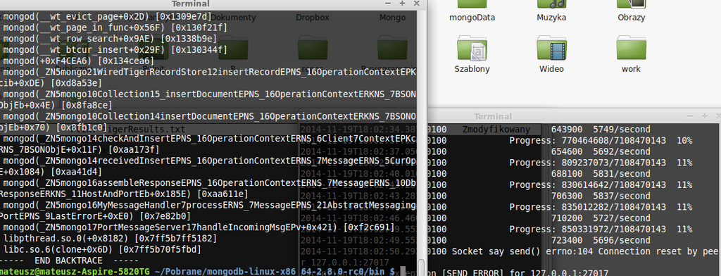

Dlatego zostałem zmuszony do zaimportowania wyłącznie kolumny **Tags** za pomocą wiredtiger.

Jednak zauważyć można dziwne zachowanie procesora przy **wiredtiger**

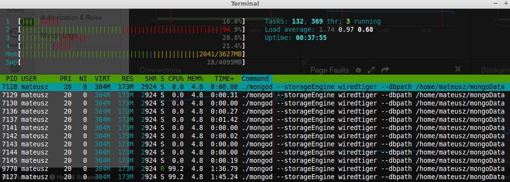

Wyniki zaimportowanych danych są przedstawione w następującej tabeli:

| Nazwa bazy | Postgres | MongoDB | MongoDB wiredtiger |
| --- | --- | --- | --- |
| Czas wrzucenia bazy | 6.10 m | 6.42 m | 8.47m |
| Ilość wrzuconych rekordów na sekundę | 16487 rekordów | 15665 rekordów | - |

Wykres dla PostgresSQL

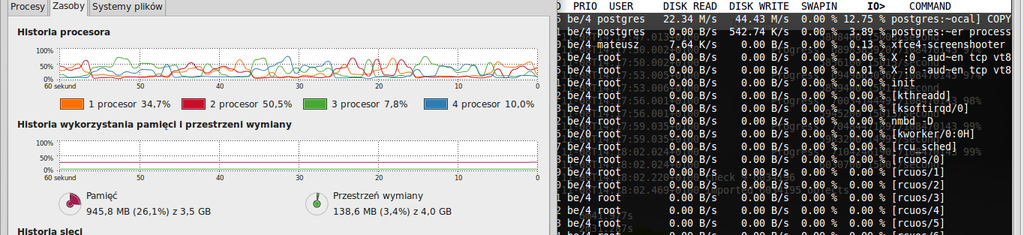

Wykres dla MongoDB

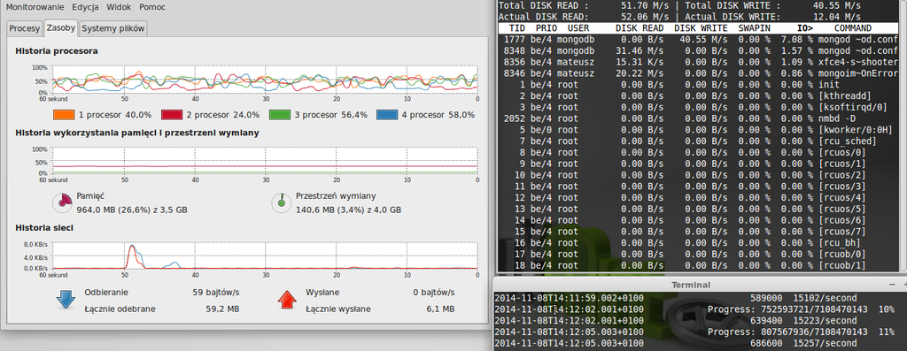

##### Wnioski:

- Większe wykorzystanie procesora możemy zaobserwować podczas importowania danych w MongoDB.
- Szybkie czasy spowodowane są użyciem dyskiem SSD.
- Wyłączenie wypisywania potwierdzenia dodania rekordów do bazy MongoDB nie zmieniło czasu importowania danych.
- PostgreSQL ma mniejsze wykorzystanie procesora niż w MongoDB w wersji 2.6.5